# Complaint Volume and Inspection Outcome Association

## Exploratory Data Analysis

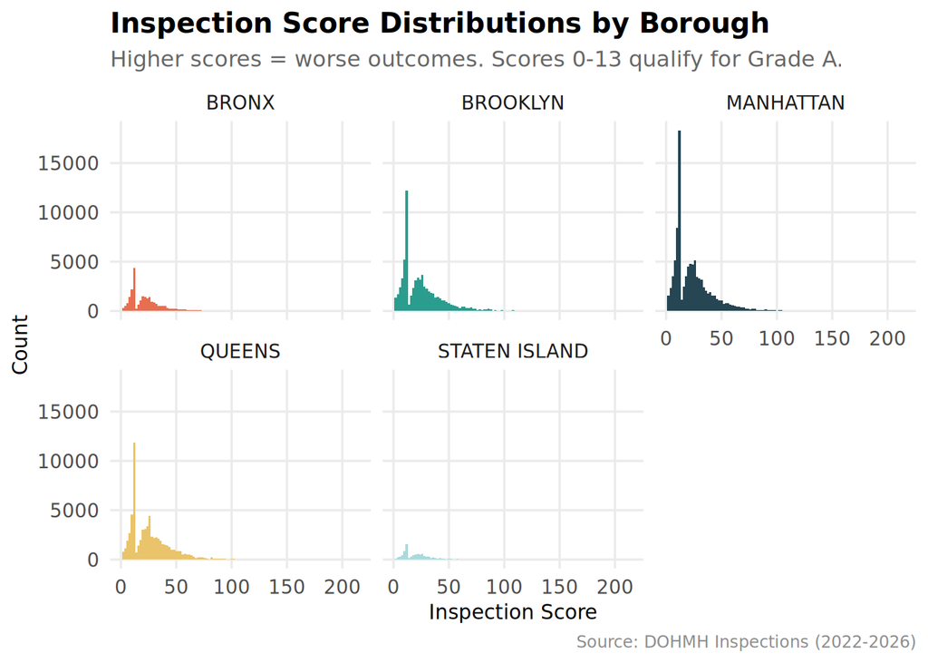

```r
# Score distributions by borough reveal baseline variation before
# modeling the complaint-score relationship
inspections |>
  filter(!is.na(score), score > 0) |>
  ggplot(aes(x = score, fill = borough)) +
  geom_histogram(binwidth = 2, show.legend = FALSE) +
  facet_wrap(~ borough, ncol = 3) +
  scale_fill_manual(values = borough_colors) +
  labs(title = "Inspection Score Distributions by Borough",
       subtitle = "Higher scores = worse outcomes. Scores 0-13 qualify for Grade A.",
       x = "Inspection Score", y = "Count",
       caption = "Source: DOHMH Inspections (2022-2026)") +
  theme_nyc()
```

```r
# Compute raw correlation before modeling to verify the relationship
# exists and assess its direction and approximate magnitude
zip_preview <- inspections |>
  group_by(zipcode, borough) |>
  summarise(avg_score = mean(score, na.rm = TRUE), .groups = "drop") |>
  left_join(complaints |> count(zipcode, name = "total_complaints"),
            by = "zipcode") |>
  filter(!is.na(total_complaints), !is.na(avg_score))

cor_raw <- cor(log1p(zip_preview$total_complaints), zip_preview$avg_score,
               use = "pairwise.complete.obs")
cat("Raw Pearson correlation (log complaints vs avg score):",
    round(cor_raw, 3), "\n")
```

```
## Raw Pearson correlation (log complaints vs avg score): 0.563
```

```r
cat("ZIP codes in preview:", nrow(zip_preview), "\n")
```

```
## ZIP codes in preview: 216
```

The raw Pearson correlation between log-transformed complaint volume and average inspection score is moderately positive, confirming that the relationship exists before any modeling adjustments. This preliminary check is important because it establishes that the main regression finding is not an artifact of the modeling choices but reflects a genuine pattern in the raw data. The log transformation of complaints is justified by the right-skewed distribution of complaint volumes across ZIP codes: a linear scale would give excessive weight to the handful of extremely high-complaint ZIP codes, while the log scale treats the difference between 10 and 100 complaints as equivalent to the difference between 100 and 1,000 complaints, which is more consistent with how complaint volume likely relates to underlying risk.

## Analysis

### Building the ZIP-Level Dataset

```r
# Aggregate to ZIP level with minimum observation requirements.
# At least 6 months of data required for stable outcome averages.
# pct_grade_a computed only from inspections with recorded grades
# to avoid treating missing grades as non-A outcomes.
insp_zip <- inspections |>
  group_by(zipcode, borough) |>
  summarise(
    avg_score     = mean(score,        na.rm = TRUE),
    pct_critical  = mean(is_critical,  na.rm = TRUE),
    pct_grade_a   = mean(grade == "A", na.rm = TRUE),
    n_inspections = n(),
    n_months      = n_distinct(month),
    .groups = "drop"
  ) |>
  filter(n_months >= 6, !is.na(avg_score))

comp_zip <- complaints |> count(zipcode, name = "total_complaints")

sq2_data <- insp_zip |>
  left_join(comp_zip, by = "zipcode") |>
  filter(!is.na(total_complaints), total_complaints > 0)

cat("ZIP-level observations:", nrow(sq2_data), "\n")
```

```
## ZIP-level observations: 196
```

### Correlation Matrix

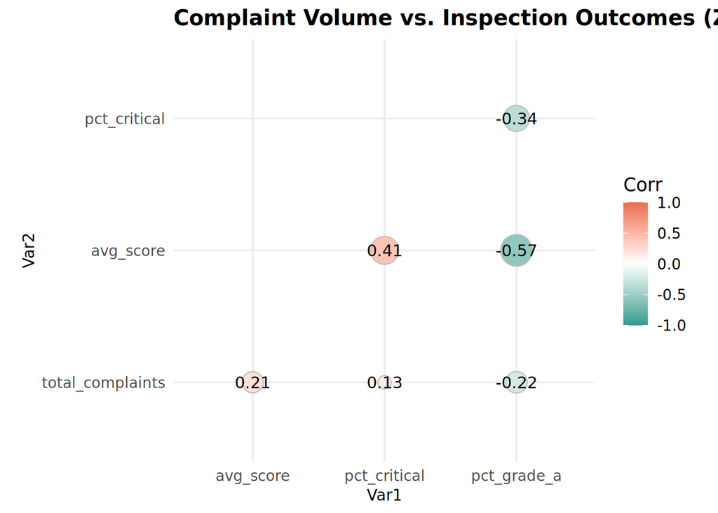

```r
# Full correlation matrix provides an overview of pairwise relationships
# among all outcome variables and complaint volume before regression
sq2_cors <- sq2_data |>
  select(total_complaints, avg_score, pct_critical, pct_grade_a) |>
  cor(use = "pairwise.complete.obs")

ggcorrplot(sq2_cors, method = "circle", type = "lower",
           lab = TRUE, lab_size = 4,
           colors = c("#2A9D8F", "white", "#E76F51"),
           title = "Complaint Volume vs. Inspection Outcomes (ZIP level)") +
  theme_nyc()
```

### Scatter Plot

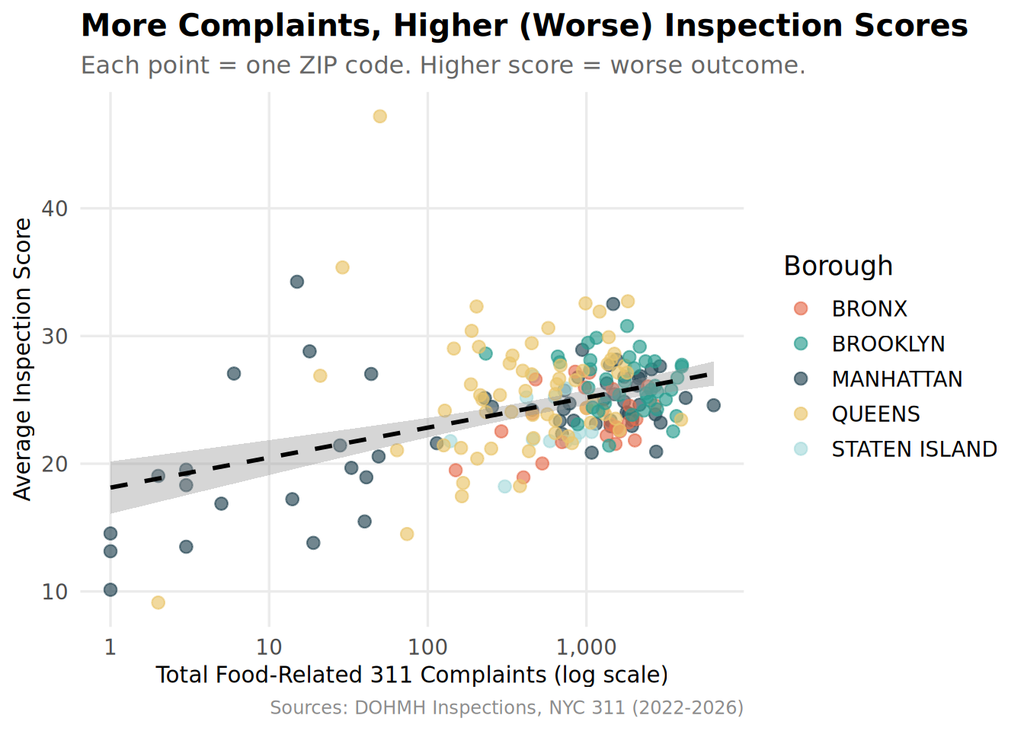

```r
p_scatter <- ggplot(sq2_data,
  aes(x = total_complaints, y = avg_score, color = borough,
      text = paste0("ZIP: ", zipcode, "<br>Borough: ", borough,
                    "<br>Avg Score: ", round(avg_score, 1),
                    "<br>Complaints: ", comma(total_complaints),
                    "<br>% Grade A: ", percent(pct_grade_a)))) +
  geom_point(alpha = 0.65, size = 2.5) +
  geom_smooth(aes(group = 1), method = "lm", se = TRUE,
              color = "black", linewidth = 1, linetype = "dashed") +
  scale_x_log10(labels = comma) +
  scale_color_manual(values = borough_colors) +
  labs(title = "More Complaints, Higher (Worse) Inspection Scores",
       subtitle = "Each point = one ZIP code. Higher score = worse outcome.",
       x = "Total Food-Related 311 Complaints (log scale)",
       y = "Average Inspection Score", color = "Borough",
       caption = "Sources: DOHMH Inspections, NYC 311 (2022-2026)") +
  theme_nyc()
p_scatter
```

### Interactive Chart

```r
# Interactive version lets readers identify individual ZIP codes
# and verify the trend is not driven by specific outliers
ggplotly(p_scatter, tooltip = "text") |>
  layout(hoverlabel = list(bgcolor = "white"))
```

[interactive chart not shown]

### OLS Regression

```r
# Log1p transformation of complaints handles zero values and captures
# the multiplicative relationship: each percentage increase in complaints
# is associated with the same absolute increase in score, rather than
# each additional complaint adding the same fixed increment.
# Borough fixed effects control for systematic geographic variation.
sq2_model <- lm(avg_score ~ log1p(total_complaints) + borough,
                data = sq2_data)

tidy(sq2_model) |>
  kable(digits = 4,
        caption = "OLS: Avg Inspection Score ~ log(Complaints) + Borough") |>
  kable_styling(bootstrap_options = c("striped","condensed"))
```

OLS: Avg Inspection Score ~ log(Complaints) + Borough

| term | estimate | std.error | statistic | p.value |
| --- | --- | --- | --- | --- |
| (Intercept) | 16.2558 | 1.4491 | 11.2179 | 0.0000 |
| log1p(total_complaints) | 1.0388 | 0.1768 | 5.8743 | 0.0000 |
| boroughBROOKLYN | 2.2444 | 0.9950 | 2.2558 | 0.0252 |
| boroughMANHATTAN | 1.0628 | 0.9470 | 1.1223 | 0.2632 |
| boroughQUEENS | 3.0513 | 0.9261 | 3.2947 | 0.0012 |
| boroughSTATEN ISLAND | 0.1643 | 1.3555 | 0.1212 | 0.9037 |

```r
glance(sq2_model) |>
  select(r.squared, adj.r.squared, p.value, nobs) |>
  kable(digits = 4, caption = "Model Fit Summary") |>
  kable_styling(bootstrap_options = c("striped","condensed"))
```

Model Fit Summary

| r.squared | adj.r.squared | p.value | nobs |
| --- | --- | --- | --- |
| 0.2339 | 0.2137 | 0 | 196 |